# Bioestadística, Zootecnia

Clase 13: Estimadores e Intervalos de Confianza

Departamento de Estadı́stica, Sede Bogotá

## Contenido

### Parte I: Fundamentos de estimación

- Parámetros, estadísticos y estimadores.
- Distribuciones muestrales y error estándar.
- Propiedades: sesgo, precisión, ECM.
- Consistencia y eficiencia relativa.

### Parte II: Intervalos de confianza

- Construcción e interpretación frecuentista.
- IC para media ($z$ y $t$) y para proporción.
- Factores, supuestos y diseños complejos.
- Aplicaciones pecuarios y errores comunes.

Fundamentos de Estimación Estadística

La estimación es el proceso de usar información de una muestra para aproximar características desconocidas de la población. Es el primer paso formal de la inferencia estadística.

## Inferencia estadística y estimación

Inferencia estadística

Proceso de usar datos de una **muestra** para sacar conclusiones sobre una **población**. Tiene dos ramas:

- **Estimación:** aproximar el valor de un parámetro ($\mu$, $p$, $\sigma^2$).
- **Prueba de hipótesis:** decidir si un parámetro cumple cierta condición (próxima clase).

Parámetro vs estadístico

|  | Población | Muestra |
| --- | --- | --- |
| Media | $\mu$ | $\bar{x}$ |
| Varianza | $\sigma^2$ | $s^2$ |
| Proporción | $p$ | $\hat{p}$ |
| Tamaño | $N$ | $n$ |

Los parámetros son **fijos pero desconocidos**; los estadísticos son **aleatorios y calculables**.

## Estimadores como funciones aleatorias de la muestra

Definición formal

Un **estimador** $\hat{\theta}$ es una función de las observaciones muestrales:
$$\hat{\theta} = g(X_1, X_2, \ldots, X_n)$$
Como los $X_i$ son variables aleatorias, $\hat{\theta}$ también lo es: tiene su propia distribución, media y varianza.

#### Estimación puntual vs por intervalo

- **Puntual:** un único valor. $\bar{x} = 5.2$ kg/animal estima el productividad promedio de aves en el Meta.
- **Por intervalo:** un rango con nivel de confianza. IC 95%: [4.8, 5.6] kg/animal. Cuantifica la incertidumbre.
- La estimación puntual sin IC omite información crucial sobre la precisión.

## Estimadores clásicos en zootecnia

| Parámetro | Estimador | Fórmula | Propiedad clave |
| --- | --- | --- | --- |
| Media $\mu$ | $\bar{X}$ | $\frac{1}{n}\sum x_i$ | Insesgado, eficiente (normal) |
| Varianza $\sigma^2$ | $S^2$ | $\frac{1}{n-1}\sum(x_i-\bar{x})^2$ | Insesgado con $n-1$ |
| Proporción $p$ | $\hat{p}$ | $x/n$ | Insesgado, consistente |
| Mediana $m$ | $\tilde{X}$ | percentil 50 muestral | Robusto a outliers |
| Máximo $\theta$ | $X_{(n)}$ | mayor observación | Sesgado; corregible |

**Ejemplo pecuario:** producción de leche (Huila), se usan $\bar{X}$ para estimar $\mu$ y $S^2$ para estimar $\sigma^2$. Para detectar producción mínima garantizada, $X_{(1)}$ (mínimo muestral) es más relevante.

Elección del estimador

No existe un estimador universalmente óptimo. La elección depende del parámetro de interés, la distribución subyacente y la robustez deseada ante valores atípicos.

## La analogía de la diana: sesgo y precisión

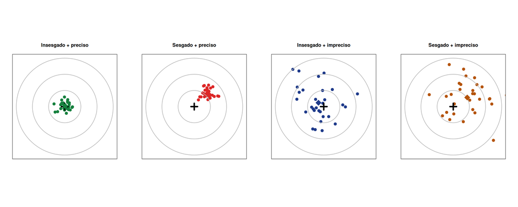

La **cruz negra** es el verdadero parámetro $\theta$. El **diamante** es la media de las estimaciones. El estimador ideal es insesgado (diamante en la cruz) y preciso (puntos concentrados).

## Distribuciones muestrales de estimadores

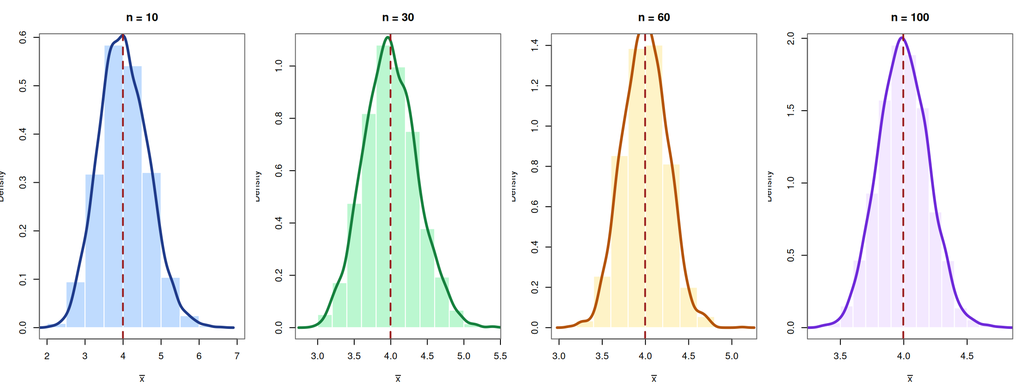

La **distribución muestral** de $\bar{X}$ se hace más estrecha y simétrica al aumentar $n$ (TLC). El SE $= \sigma/\sqrt{n}$ cuantifica esa concentración.

## Variabilidad muestral y el error estándar

Variabilidad muestral

Distintas muestras del mismo lote producen distintos $\bar{x}$. Esa dispersión *entre* muestras es la **variabilidad muestral**, inherente al proceso, predecible y medible.

Error estándar

Desviación estándar de la distribución muestral:
$$\text{SE}(\bar{X}) = \frac{\sigma}{\sqrt{n}}$$
$$\text{SE}(\hat{p}) = \sqrt{\frac{p(1-p)}{n}}$$

SE estimado

Como $\sigma$ y $p$ son desconocidos:
$$\widehat{\text{SE}}(\bar{X}) = \frac{s}{\sqrt{n}}$$
$$\widehat{\text{SE}}(\hat{p}) = \sqrt{\frac{\hat{p}(1-\hat{p})}{n}}$$

Distinción clave: $s$ vs SE

$s$ mide variabilidad **dentro** de la muestra (entre individuos). El SE mide variabilidad **entre** muestras distintas (del estimador). Son conceptualmente distintos.

## Propiedades de los estimadores

Insesgamiento

$$E(\hat{\theta}) = \theta$$
No hay desviación sistemática. $\bar{X}$, $\hat{p}$ y $s^2$ (con $n-1$) son insesgados.

Precisión

$\text{Var}(\hat{\theta})$ pequeña.

Valores concentrados alrededor de su media. Mayor $n$ $\Rightarrow$ mayor precisión.

Consistencia

$$\hat{\theta} \xrightarrow{P} \theta \text{ si } n \to \infty$$
Condición suficiente: $\text{ECM}(\hat{\theta}) \to 0$. $\bar{X}$ es consistente por la LGN.

**Eficiencia relativa**

Entre dos insesgados:
$$e(\hat{\theta}_1, \hat{\theta}_2) = \frac{\text{Var}(\hat{\theta}_2)}{\text{Var}(\hat{\theta}_1)}$$
Si $e > 1$, $\hat{\theta}_1$ es más eficiente.

Un buen estimador debe ser **insesgado**, **preciso** y **consistente**. La eficiencia relativa elige el mejor entre varios candidatos.

## Demostración: insesgamiento de $\bar{X}$ y $S^2$

Insesgamiento de $\bar{X}$

$$E(\bar{X}) = E\!\left(\frac{1}{n}\sum_{i=1}^n X_i\right) = \frac{1}{n}\sum_{i=1}^n E(X_i) = \frac{1}{n}\cdot n\mu = \mu \quad\blacksquare$$
La linealidad de la esperanza es la clave: $E(aX)=aE(X)$ y $E(X+Y)=E(X)+E(Y)$.

Por qué $s^2$ usa $n-1$

El estimador con $n$ en el denominador tiene sesgo:
$$E\!\left(\frac{1}{n}\sum(X_i-\bar{X})^2\right) = \frac{n-1}{n}\sigma^2 \neq \sigma^2$$
Corrigiendo con $n-1$:
$$E(S^2) = E\!\left(\frac{\sum(X_i-\bar{X})^2}{n-1}\right) = \sigma^2 \quad\blacksquare$$

El factor $n-1$ se llama **grados de libertad**: al estimar $\mu$ con $\bar{x}$, se “consume” 1 grado de libertad, dejando solo $n-1$ piezas de información independientes para estimar $\sigma^2$.

## ¿Cuándo usar $z$ y cuándo usar $t$?

Usar $z_{\alpha/2}$ (Normal estándar)

- $\sigma$ es **conocida** (datos históricos confiables).
- Muestra **grande** ($n \geq 30$), TLC garantiza normalidad de $\bar{X}$.
- IC para **proporciones** con condición $n\hat{p} \geq 5$ y $n(1-\hat{p}) \geq 5$.

Usar $t_{n-1,\,\alpha/2}$ (Student)

- $\sigma$ es **desconocida** y se estima con $s$.
- Muestra **pequeña** ($n < 30$), distribución original aproximadamente normal.
- Cuando $n \to \infty$, $t_{n-1} \to z$: la diferencia es despreciable para $n \geq 100$.

Regla práctica

En la práctica, $\sigma$ rara vez se conoce: **use siempre $t$** para datos continuos. Para $n \geq 30$ la diferencia entre $z$ y $t$ es mínima y ambos son válidos.

## Comparación gráfica: Normal vs $t$ de Student

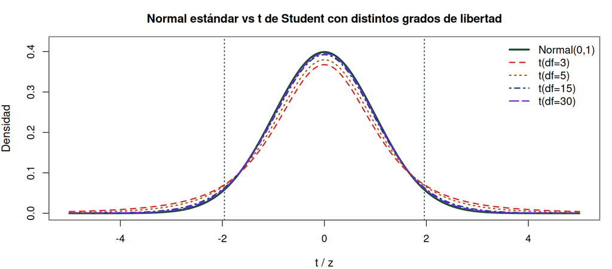

La $t$ tiene **colas más pesadas** que la Normal: da valores críticos mayores y produce ICs más anchos. Con $df \geq 30$ las diferencias son menores al 5%; para $df \geq 100$ son despreciables.

## Insesgamiento, sesgo y error cuadrático medio

Sesgo

$$B(\hat{\theta}) = E(\hat{\theta}) - \theta$$

- $B = 0$: **insesgado**, sin desviación sistemática.
- $B > 0$: sobreestima en promedio.
- $B < 0$: subestima en promedio.

$\hat{\sigma}^2 = \frac{1}{n}\sum(x_i-\bar{x})^2$ es sesgado; dividir por $n-1$ corrige el sesgo.

Error cuadrático medio

Integra sesgo y varianza en una sola medida:
$$\text{ECM}(\hat{\theta}) = \text{Var}(\hat{\theta}) + [B(\hat{\theta})]^2$$
Para insesgados: $\text{ECM} = \text{Var}(\hat{\theta})$.

Precisión vs exactitud

Preciso (baja varianza) $\neq$ exacto (sin sesgo). El ECM penaliza ambos defectos simultáneamente.

## Consistencia y eficiencia: Teorema Central del Límite

Consistencia y TLC

$\hat{\theta}_n$ es consistente si $P(|\hat{\theta}_n - \theta| > \varepsilon) \to 0$.

Por el **TLC**, para $n$ grande:
$$Z = \frac{\bar{X} - \mu}{\sigma/\sqrt{n}} \xrightarrow{d} N(0,1)$$
Esto garantiza la aproximación normal en inferencia independientemente de la distribución original, siempre que $\sigma^2 < \infty$.

Eficiencia relativa: ejemplo

Para $X \sim N(\mu, \sigma^2)$:

- $\text{Var}(\bar{X}) = \sigma^2/n$
- $\text{Var}(\tilde{X}) = \pi\sigma^2/(2n)$ (mediana)

$$e(\bar{X}, \tilde{X}) = \frac{\pi\sigma^2/(2n)}{\sigma^2/n} = \frac{\pi}{2} \approx 1.57$$

$\bar{X}$ es un 57% más eficiente que la mediana para datos normales.

## Consistencia: convergencia visual en R

[figure not shown]

Intervalos de Confianza

Un intervalo de confianza es un rango de valores calculado desde la muestra que, bajo repeticiones del experimento, contiene el verdadero parámetro con una probabilidad preestablecida.

## Construcción conceptual del intervalo de confianza

Derivación desde el TLC

Por el TLC: $Z = \dfrac{\bar{X}-\mu}{\sigma/\sqrt{n}} \approx N(0,1)$

$$P\!\left(-z_{\alpha/2} \leq Z \leq z_{\alpha/2}\right) = 1-\alpha$$

Despejando $\mu$:

$$P\!\left(\bar{X} - z_{\alpha/2}\frac{\sigma}{\sqrt{n}} \leq \mu \leq \bar{X} + z_{\alpha/2}\frac{\sigma}{\sqrt{n}}\right) = 1-\alpha$$

#### Anatomía del IC

- **Centro:** estimador puntual $\bar{x}$.
- **Semiancho:** margen de error $e = z_{\alpha/2}\,\text{SE}$.
- $\text{IC}_{1-\alpha} = [\,\bar{x} - e,\;\bar{x} + e\,]$
- **Nivel de confianza** $1-\alpha$: proporción de ICs que contienen $\mu$.
- **Nivel de significancia** $\alpha$: proporción que no lo contiene.

## Interpretación frecuentista y cobertura

Interpretación incorrecta

“Hay 95% de probabilidad de que $\mu$ esté en [4.8, 5.6].”

Incorrecto: $\mu$ es un valor **fijo**. Una vez construido el IC, el parámetro está o no está dentro, sin probabilidad.

Interpretación correcta

“Si repitiéramos el muestreo muchas veces, el **95% de los ICs** construidos de la misma forma contendría a $\mu$.”

El 95% describe la **frecuencia de éxito del método**, no del intervalo particular.

**Cobertura nominal vs real:** un IC al 95% tiene cobertura nominal de 0.95. La cobertura real puede diferir si los supuestos (normalidad, independencia) no se cumplen.

## Cobertura del IC: simulación en R

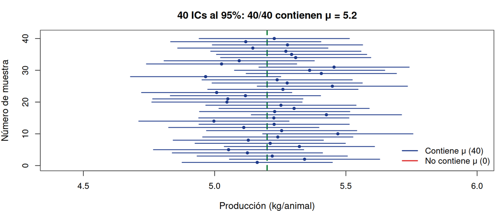

## IC para la media: $\sigma$ conocida

Fórmula y tabla $z$

$$\bar{x} \pm z_{\alpha/2}\,\frac{\sigma}{\sqrt{n}}$$

| Confianza | $\alpha$ | $z_{\alpha/2}$ |
| --- | --- | --- |
| 90% | 0.10 | 1.645 |
| 95% | 0.05 | 1.960 |
| 99% | 0.01 | 2.576 |

Válido cuando $\sigma$ se conoce o $n \geq 30$ (TLC).

Ejemplo: producción de leche, Huila

$\sigma = 0.8$ L/animal (histórica), $n = 64$, $\bar{x} = 2.6$ kg.

IC al 95%:
$$2.6 \pm 1.96 \times \frac{0.8}{\sqrt{64}} = 2.6 \pm 0.196$$
$$\text{IC}_{95\%}: [2.40,\; 2.80] \text{ L/animal}$$

```r
xbar <- 2.6; sigma <- 0.8; n <- 64
round(xbar + c(-1,1)*1.96*sigma/sqrt(n), 3)
```

```
[1] 2.404 2.796
```

## IC para la media: ejemplo paso a paso

Paso 1: datos

Peso de terneros Hass, Antioquia.

$n = 49$ frutos, $\bar{x} = 278$ g, $s = 28$ g.

Queremos IC al 95%.

Paso 2: elegir distribución

$n = 49 \geq 30$ y $\sigma$ desconocida (usamos $s$).

$t_{48,\,0.025} = 2.011$

(Para $n \geq 30$, $t \approx z$)

Paso 3: calcular

$e = 2.011 \times \dfrac{28}{\sqrt{49}} = 8.04$ g

$[278-8, 278+8]$

$= [270,\; 286]$ g

**Paso 4: interpretar**

Con 95% de confianza, el peso promedio real de los terneros Hass está entre 270 y 286 g.

```r
xbar <- 278; s <- 28; n <- 49
e <- qt(0.975, df = n-1) * s / sqrt(n)
cat("Margen de error:", round(e, 2), "g\n")
```

```
Margen de error: 8.04 g
```

```r
cat("IC 95%: [", round(xbar-e,1), ",", round(xbar+e,1), "] g\n")
```

```
IC 95%: [ 270 , 286 ] g
```

## IC para la media: $\sigma$ desconocida

Distribución $t$ de Student

Cuando $\sigma$ es desconocida se estima con $s$:
$$T = \frac{\bar{X}-\mu}{s/\sqrt{n}} \sim t_{n-1}$$
$$\bar{x} \pm t_{n-1,\,\alpha/2}\,\frac{s}{\sqrt{n}}$$
La distribución $t$ tiene colas más pesadas que la Normal: IC más ancho para $n$ pequeño. Cuando $n \to \infty$, $t \to z$.

Ejemplo: leche bovina, Nariño

$n = 16$ vacas, $\bar{x} = 17.4$ L/día, $s = 2.8$ L.

$t_{15,\,0.025} = 2.131$

$$17.4 \pm 2.131 \times \frac{2.8}{\sqrt{16}} = 17.4 \pm 1.49$$
$$\text{IC}_{95\%}: [15.9,\; 18.9] \text{ L/día}$$

```r
xbar <- 17.4; s <- 2.8; n <- 16
round(xbar + c(-1,1)*qt(0.975, n-1)*s/sqrt(n), 2)
```

```
[1] 15.91 18.89
```

## Resumen: estimadores e IC para una media

Insesgamiento y sesgo

$$B(\hat{\theta}) = E(\hat{\theta}) - \theta$$
$B = 0$ → **insesgado**: sin desviación sistemática.

$\bar{X}$, $\hat{p}$ y $S^2$ (con $n-1$) son insesgados.

ECM, consistencia y error estándar

$$\text{ECM}(\hat{\theta}) = \text{Var}(\hat{\theta}) + B^2 \quad \text{(preciso} \neq \text{exacto)}$$
**Consistencia:** $\hat{\theta}\xrightarrow{P}\theta$ cuando $n\to\infty$ si $\text{ECM}\to 0$.

$\widehat{\text{SE}}(\bar{X})=\dfrac{s}{\sqrt{n}}$ $\widehat{\text{SE}}(\hat{p})=\sqrt{\dfrac{\hat{p}(1-\hat{p})}{n}}$

IC para una media

| Situación | Fórmula |
| --- | --- |
| $\sigma$ conocida o $n\geq30$ | $\bar{x}\pm z_{\alpha/2}\,\dfrac{\sigma}{\sqrt{n}}$ |
| $\sigma$ desconocida | $\bar{x}\pm t_{n-1,\,\alpha/2}\,\dfrac{s}{\sqrt{n}}$ |

**Interpretación:** el $(1-\alpha)\times 100\%$ de los ICs construidos por el método contienen $\mu$, no el intervalo particular.

**Amplitud:** $2e = 2\,z_{\alpha/2}\,s/\sqrt{n}$. Cuadruplicar $n$ reduce $e$ a la mitad.

## ¿Cuántas observaciones necesito?

Fórmula general

Despejar $n$ de $e = z_{\alpha/2}\,\dfrac{\sigma}{\sqrt{n}}$:

$$n = \left(\frac{z_{\alpha/2}\,\sigma}{e}\right)^2$$

donde $e$ es el **margen de error máximo admisible**. Si $\sigma$ es desconocida, usar un valor piloto, literatura, o la regla $\sigma \approx \text{rango}/4$.

Regla práctica

Reducir el margen a la **mitad** requiere multiplicar $n$ por **4**.

Reducir el margen a la **tercera parte** requiere multiplicar $n$ por **9**.

$$n \propto \frac{1}{e^2}$$

Ejemplo: producción de leche, Huila

Un profesional en zootecnia quiere estimar el productividad medio con un margen de error de **±0.2 L/animal** al 95% de confianza. Estudios previos reportan $\sigma \approx 0.8$ kg.

1. **Datos:** $e = 0.2$, $\sigma = 0.8$, $z_{0.025} = 1.96$
2. **Cálculo:**
   $$n = \left(\frac{1.96 \times 0.8}{0.2}\right)^2 = \left(\frac{1.568}{0.2}\right)^2 = (7.84)^2 = 61.47$$
3. **Decisión:** $n = \lceil 61.47 \rceil = \mathbf{62}$ animales. *(Siempre redondear hacia arriba.)*
4. **Verificación:** si se quisiera $e = 0.1$ kg (la mitad), se necesitarían $62 \times 4 = \mathbf{248}$ animales.

## IC para diferencia de medias

Fórmula (varianzas iguales, $\sigma$ desconocida)

$$(\bar{x}_1 - \bar{x}_2) \pm t_{n_1+n_2-2,\,\alpha/2} \cdot S_p\sqrt{\frac{1}{n_1}+\frac{1}{n_2}}$$
donde la varianza combinada (*pooled*) es:
$$S_p^2 = \frac{(n_1-1)S_1^2 + (n_2-1)S_2^2}{n_1+n_2-2}$$
Si IC contiene 0: no hay diferencia significativa entre las medias.

Ejemplo: dos dietas para aves, Meta

Dieta A: $n_1=20$, $\bar{x}_1=6.1$, $s_1=0.9$ kg/animal. Dieta B: $n_2=20$, $\bar{x}_2=5.4$, $s_2=0.8$ kg/animal.

1. **Varianza combinada:** $S_p^2 = \dfrac{19(0.81)+19(0.64)}{38} = \dfrac{27.55}{38} = 0.725$; $\;S_p=0.851$
2. **Error estándar:** $\text{SE}=0.851\sqrt{\tfrac{1}{20}+\tfrac{1}{20}}=0.851\times 0.316=0.269$
3. **Valor crítico:** $t_{38,\,0.025}\approx 2.024$; $e=2.024\times 0.269=0.545$
4. **IC 95%:** $(6.1-5.4)\pm 0.545 \;\Rightarrow\; [0.155,\;1.245]$ kg/animal

$0\notin[0.155,\,1.245]$ → la dieta A produce significativamente más que la B.

## IC para medias pareadas

Fórmula para datos dependientes

Cuando las observaciones son pares $(x_{i1}, x_{i2})$ (antes/después, mismo lote con dos tratamientos):
$$\bar{d} \pm t_{n-1,\,\alpha/2}\,\frac{s_d}{\sqrt{n}}$$
donde $d_i = x_{i1} - x_{i2}$, $\bar{d} = \overline{d_i}$, $s_d$ = desviación estándar de las diferencias.

Ejemplo: humedad (%) antes y después de alimentación, Tolima

$n=5$ corrales; $d_i = \text{después} - \text{antes}$:

| Corral | Antes | Después | $d_i$ |
| --- | --- | --- | --- |
| 1 | 28 | 36 | 8 |
| 2 | 31 | 37 | 6 |
| 3 | 25 | 34 | 9 |
| 4 | 33 | 39 | 6 |
| 5 | 27 | 33 | 6 |

1. $\bar{d}=(8+6+9+6+6)/5=35/5=7.0\%$
2. $s_d^2=\tfrac{(1)^2+(−1)^2+(2)^2+(−1)^2+(−1)^2}{4}=\tfrac{8}{4}=2{,}0\;$; $\;s_d=1.414$
3. $\text{SE}=1.414/\sqrt{5}=0.632$; $\;t_{4,\,0.025}=2.776$; $\;e=2.776\times0.632=1.755$
4. $\text{IC}_{95\%}: 7.0\pm1.755 \;\Rightarrow\; [5.24\%,\;8.76\%]$

## IC para una proporción

Intervalo de Wald (grandes muestras)

$$\hat{p} \pm z_{\alpha/2}\sqrt{\frac{\hat{p}(1-\hat{p})}{n}}$$

Condición de validez: $n\hat{p} \geq 5$ y $n(1-\hat{p}) \geq 5$.

Para muestras pequeñas o $\hat{p}$ extremos: intervalo exacto de Wilson o Clopper-Pearson.

Ejemplo: mastitis en hatos, Huila

$n = 200$, $x = 54$ animales con mastitis $\Rightarrow \hat{p} = 0.27$.

Condición: $200 \times 0.27 = 54 \geq 5$ ✓

$$0.27 \pm 1.96\sqrt{\frac{0.27 \times 0.73}{200}} = 0.27 \pm 0.062$$

$$\text{IC}_{95\%}: [0.208,\; 0.332]$$

```r
p_hat <- 54/200; n <- 200
round(p_hat + c(-1,1)*1.96*sqrt(p_hat*(1-p_hat)/n), 3)
```

```
[1] 0.208 0.332
```

## IC de Wilson: proporciones con muestras pequeñas

Intervalo de Wilson

El intervalo de Wald falla cuando $\hat{p}$ es extremo (cercano a 0 o 1) o $n$ es pequeño. El intervalo de **Wilson** es más preciso:
$$\frac{\hat{p} + \frac{z_{\alpha/2}^2}{2n} \pm z_{\alpha/2}\sqrt{\frac{\hat{p}(1-\hat{p})}{n}+\frac{z_{\alpha/2}^2}{4n^2}}}{1+\frac{z_{\alpha/2}^2}{n}}$$
Recomendado siempre que $n\hat{p} < 5$ o $n(1-\hat{p}) < 5$.

Comparación: Wald vs Wilson

$n = 20$ animales, $x = 2$ enfermas ($\hat{p} = 0.10$). Condición: $20 \times 0.10 = 2 < 5$ → Wald no válido.

```r
n <- 20; x <- 2; p <- x/n; z <- 1.96
# Wald
wald <- p + c(-1,1)*z*sqrt(p*(1-p)/n)
# Wilson
num  <- p + z^2/(2*n)
den  <- 1 + z^2/n
rad  <- z*sqrt(p*(1-p)/n + z^2/(4*n^2))/den
wilson <- c(num/den - rad, num/den + rad)
cat("Wald  :", round(wald, 3), "\n")
```

```
Wald  : -0.031 0.231
```

```r
cat("Wilson:", round(wilson, 3), "\n")
```

```
Wilson: 0.028 0.301
```

## IC para la varianza: distribución chi-cuadrado

Fórmula

Si $X_1,\ldots,X_n \sim N(\mu,\sigma^2)$, entonces:
$$\frac{(n-1)S^2}{\sigma^2} \sim \chi^2_{n-1}$$
El IC al $(1-\alpha)$ para $\sigma^2$ es:
$$\left[\frac{(n-1)S^2}{\chi^2_{n-1,\,\alpha/2}},\;\frac{(n-1)S^2}{\chi^2_{n-1,\,1-\alpha/2}}\right]$$
El IC para $\sigma^2$ es **asimétrico**.

Ejemplo: variabilidad de productividad, Nariño

$n=25$ corrales de cerdos, $s^2=1.44$ (kg/animal)$^2$, IC al 95%.

1. **Grados de libertad:** $df = n-1 = 24$
2. **Valores críticos (tabla $\chi^2$):** $\chi^2_{24,\,0.975}=39.36$ y $\chi^2_{24,\,0.025}=12.40$
3. **IC para $\sigma^2$:**
   $$\left[\frac{24\times1.44}{39.36},\;\frac{24\times1.44}{12.40}\right]=[0.878,\;2.787]$$
4. **IC para $\sigma$:** $[\sqrt{0.878},\;\sqrt{2.787}]=[0.94,\;1.67]$ kg/animal

El IC es **asimétrico**: la distribución $\chi^2$ tiene cola derecha más larga.

## Tabla resumen: IC para distintos parámetros

| Parámetro | Condición | Estadístico pivote | Intervalo |
| --- | --- | --- | --- |
| $\mu$ ($\sigma$ conocida) | cualquier $n$ | $Z = \frac{\bar{X}-\mu}{\sigma/\sqrt{n}}$ | $\bar{x} \pm z_{\alpha/2}\,\sigma/\sqrt{n}$ |
| $\mu$ ($\sigma$ desconocida) | pop. normal | $T = \frac{\bar{X}-\mu}{S/\sqrt{n}}\sim t_{n-1}$ | $\bar{x} \pm t_{n-1}\,s/\sqrt{n}$ |
| $\mu_1-\mu_2$ | indep., var. iguales | $T \sim t_{n_1+n_2-2}$ | $(\bar{x}_1-\bar{x}_2) \pm t\cdot S_p\sqrt{1/n_1+1/n_2}$ |
| $p$ | $n\hat{p}\geq5$, $n(1-\hat{p})\geq5$ | $Z = \frac{\hat{p}-p}{\text{SE}}$ | $\hat{p} \pm z_{\alpha/2}\sqrt{\hat{p}(1-\hat{p})/n}$ |
| $\sigma^2$ | pop. normal | $\chi^2_{n-1} = (n-1)S^2/\sigma^2$ | $\left[\frac{(n-1)s^2}{\chi^2_u},\frac{(n-1)s^2}{\chi^2_l}\right]$ |

Todos los ICs tienen la misma estructura: **estimador ± factor crítico × error estándar**. Lo que varía es el estadístico pivote y su distribución.

## Nivel de confianza, significancia y margen de error

Nivel de confianza $1-\alpha$

Proporción de ICs (bajo repetición) que contienen $\theta$. Valores usuales: 90%, 95%, 99%.

Mayor confianza $\Rightarrow$ $z_{\alpha/2}$ mayor $\Rightarrow$ IC más ancho.

Nivel de significancia $\alpha$

$\alpha = 1-(1-\alpha)$: proporción de ICs que *no* contienen $\theta$. Para IC al 95%: $\alpha = 0.05$.

Directamente vinculado al error tipo I en pruebas de hipótesis.

Margen de error

$$e = z_{\alpha/2} \cdot \widehat{\text{SE}}(\hat{\theta})$$
Semiancho del IC. Refleja la precisión de la estimación.

Media: $e = z_{\alpha/2}\,s/\sqrt{n}$

Proporción: $e = z_{\alpha/2}\sqrt{\hat{p}(1-\hat{p})/n}$

$\text{IC} = \hat{\theta} \pm e$. Reducir $e$ a la mitad (manteniendo la confianza) requiere **cuadruplicar** $n$.

Factores, Supuestos y Diseños

El ancho del IC depende de $n$, $\sigma$, el nivel de confianza y el diseño muestral. Conocer estos factores permite planificar estudios con la precisión requerida.

## Factores que afectan la amplitud del IC

Tamaño de muestra $n$

$e \propto 1/\sqrt{n}$. Cuadruplicar $n$ **reduce el margen a la mitad**. El efecto es decreciente: pasar de 10 a 40 ayuda más que de 1000 a 4000.

Variabilidad $\sigma$

$e \propto \sigma$. Mayor heterogeneidad en el lote $\Rightarrow$ IC más amplio. Estratificación o diseño experimental reducen $\sigma$ efectiva.

Nivel de confianza

$e \propto z_{\alpha/2}$. Pasar de 95% a 99% aumenta $z$ de 1.96 a 2.576: el IC crece 31%. Mayor certeza $\Rightarrow$ intervalo más amplio.

Amplitud total: $2e = 2\,z_{\alpha/2}\,\sigma/\sqrt{n}$. Para reducir la amplitud a la mitad manteniendo la confianza fija, se necesita **cuadruplicar** $n$.

## Influencia de la variabilidad poblacional

$\sigma$ grande: IC amplio

Una población **heterogénea** produce estimadores más variables: necesitamos $n$ mayor para el mismo margen de error.

Ejemplo: dietas con alto contenido variable de contenido proteico ($\sigma = 5$ g/kg) requieren más muestras que dietas uniformes ($\sigma = 1$ g/kg) para el mismo $e$.

$$n \propto \sigma^2 \quad \text{(para } e \text{ y } \alpha \text{ fijos)}$$

#### Estrategias para reducir $\sigma$

- **Estratificación:** dividir la población en grupos homogéneos y muestrear dentro de cada uno, reduce la varianza efectiva del estimador.
- **Covariables:** usar información auxiliar (ej. área del lote) en estimación por razón o regresión.
- **Medición más precisa:** mejorar el protocolo de campo reduce el error de medición, parte de $\sigma$.

## Estrategias para reducir la amplitud del IC

Aumentar $n$

El método más directo. Efecto $\propto 1/\sqrt{n}$: costoso para ganancias pequeñas. Pasar de $n=100$ a $n=400$ reduce el margen a la mitad.

Estratificar

Dividir en estratos homogéneos antes de muestrear. Puede reducir la varianza efectiva significativamente sin aumentar $n$ total.

Reducir confianza

Pasar de 99% a 95% reduce $z$ de 2.576 a 1.96 (reducción del 24%). Justificable si 95% es suficiente para la decisión.

```r
sigma <- 1.5; e_obj <- 0.3; z95 <- 1.96; z99 <- 2.576
cat("n (95%, MAS):", ceiling((z95*sigma/e_obj)^2), "\n")
```

```
n (95%, MAS): 97
```

```r
cat("n (99%, MAS):", ceiling((z99*sigma/e_obj)^2), "\n")
```

```
n (99%, MAS): 166
```

```r
cat("n (95%, DEFF=0.7):", ceiling((z95*sigma/e_obj)^2 * 0.7), "\n")
```

```
n (95%, DEFF=0.7): 68
```

## Relación entre $n$ y precisión del IC

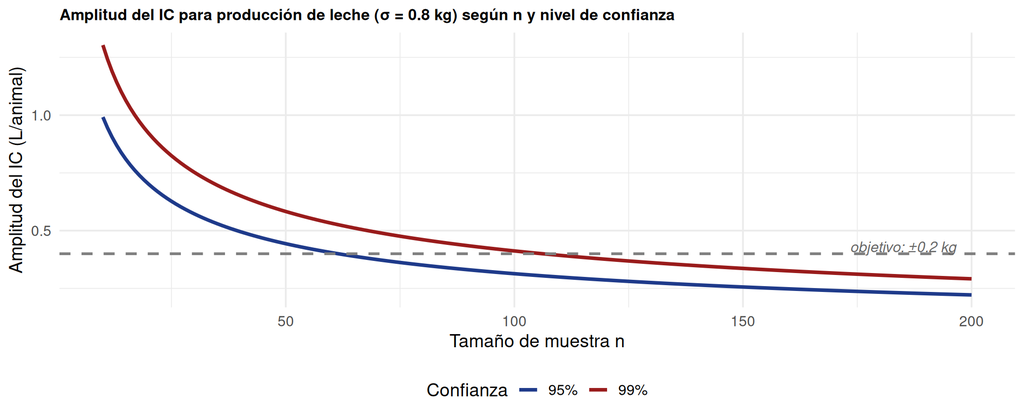

## Supuestos de inferencia estadística

#### Supuestos del IC clásico

- **Independencia:** las observaciones no se afectan entre sí. Se viola al muestrear animales adyacentes sin modelar autocorrelación espacial.
- **Normalidad o TLC:** para $n$ pequeño se requiere distribución normal de los datos. Para $n \geq 30$ el TLC garantiza la aproximación.
- **Diseño probabilístico:** la muestra debe provenir de un diseño que garantice representatividad.

#### Cobertura nominal vs real

- Los ICs clásicos son *asintóticamente* válidos: su cobertura real converge a $1-\alpha$ cuando $n \to \infty$.
- Para $n$ pequeño y distribución sesgada, la cobertura real puede diferir de la nominal.
- **Soluciones:** usar distribución $t$, transformaciones logarítmicas, o bootstrap.

## Verificación de supuestos en R

QQ-plot y prueba de Shapiro-Wilk

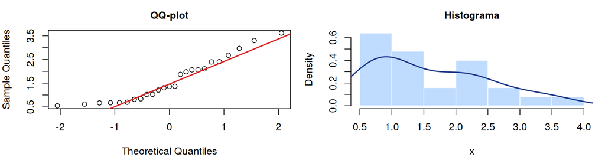

```r
set.seed(5)
x <- rgamma(25, shape=3, scale=0.5)  # productividad asimétrico
par(mfrow=c(1,2), mar=c(4,4,2.5,1), family="sans")
qqnorm(x, main="QQ-plot", cex.main=1.0); qqline(x, col="#dc2626", lwd=2)
hist(x, probability=TRUE, main="Histograma", col="#bfdbfe",
     border="white", cex.main=1.0)
lines(density(x), col="#1e3a8a", lwd=2)
```

```r
shapiro.test(x)   # H0: normalidad; p < 0.05 → rechazar
```

```
    Shapiro-Wilk normality test

data:  x
W = 0.91042, p-value = 0.03114
```

#### ¿Qué hacer si se violan los supuestos?

- **Distribución no normal, n pequeño:** usar transformación logarítmica o bootstrap.
- **Datos dependientes (series, corrales adyacentes):** modelar la autocorrelación antes de calcular el IC.
- **Outliers extremos:** investigar causa; si son errores, corregir; si son reales, usar IC robusto (mediana + bootstrap).

## Corrección por población finita e IC bajo diseños complejos

FPC en el IC

Cuando $n/N > 0.05$ (muestra apreciable de la población):
$$\bar{x} \pm z_{\alpha/2}\,\frac{s}{\sqrt{n}}\sqrt{1-\frac{n}{N}}$$
El FPC $\sqrt{1-n/N}$ reduce el SE real. Para $n/N \leq 0.05$ es despreciable.

IC bajo muestreo estratificado

$$\bar{x}_{st} \pm z_{\alpha/2}\sqrt{\sum_{h=1}^H W_h^2\,\frac{s_h^2}{n_h}\!\left(1-\frac{n_h}{N_h}\right)}$$
Generalmente más estrecho que el MAS porque reduce la varianza entre estratos.

**DEFF:** $\text{Var}_{\text{diseño}} / \text{Var}_{\text{MAS}}$. DEFF $< 1$ indica diseño más eficiente que el MAS.

Aplicar fórmulas de MAS a datos de muestreo complejo (estratificado, conglomerados) produce ICs con cobertura incorrecta. Siempre usar el estimador de varianza apropiado para el diseño.

## IC bajo muestreo por conglomerados

Fórmula

Sean $m$ conglomerados seleccionados de $M$ totales, con media $\bar{x}_i$ en el grupo $i$:

$$\bar{x}_{cl} \pm z_{\alpha/2}\sqrt{\frac{s_c^2}{m}\!\left(1-\frac{m}{M}\right)}$$

donde $s_c^2 = \frac{1}{m-1}\sum(\bar{x}_i - \bar{x}_{cl})^2$ es la varianza **entre** conglomerados.

Ejemplo: leche en Nariño (10 veredas de 80)

```r
set.seed(3)
medias_veredas <- c(17.1,18.3,16.8,19.2,17.5,
                    18.0,16.5,19.8,17.3,18.6)
m <- 10; M <- 80
xbar_cl <- mean(medias_veredas)
sc2     <- var(medias_veredas)
e_cl    <- 1.96*sqrt(sc2/m*(1-m/M))
cat("IC 95%: [", round(xbar_cl-e_cl,2), ",",
    round(xbar_cl+e_cl,2), "] L/día\n")
```

```
IC 95%: [ 17.29 , 18.53 ] L/día
```

## Efecto de diseño: concepto y cálculo

Definición del DEFF

El **efecto de diseño** mide la eficiencia relativa del diseño usado frente al MAS de igual $n$:
$$\text{DEFF} = \frac{\widehat{\text{Var}}_{\text{diseño}}(\bar{x})}{\widehat{\text{Var}}_{\text{MAS}}(\bar{x})} = \frac{\widehat{\text{Var}}_{\text{diseño}}(\bar{x})}{s^2/n}$$

- DEFF $< 1$: el diseño es **más eficiente** que el MAS (ej. estratificado bien hecho).
- DEFF $> 1$: el diseño es **menos eficiente** (ej. conglomerados homogéneos).

#### Uso del DEFF en práctica

- **Tamaño de muestra ajustado:** $n_{\text{real}} = n_{\text{MAS}} \times \text{DEFF}$.
- **IC ajustado:** multiplicar el SE del MAS por $\sqrt{\text{DEFF}}$.
- Software como R (`survey`) y SPSS calculan el DEFF automáticamente al declarar el diseño complejo.

## Comparación de ICs entre diseños muestrales

| Diseño | Estimador de varianza | DEFF típico | IC relativo a MAS |
| --- | --- | --- | --- |
| MAS | $s^2/n \cdot (1-n/N)$ | 1.00 | Referencia |
| Estratificado | $\sum W_h^2 s_h^2/n_h$ | $< 1$ | Más estrecho si estratos homogéneos |
| Conglomerados | $s_c^2/m \cdot (1-m/M)$ | $> 1$ | Más amplio si grupos homogéneos |
| Sistemático | $\approx s^2/n$ | $\approx 1$ | Similar a MAS sin periodicidad |

El estratificado siempre mejora (o iguala) al MAS cuando los estratos son más homogéneos internamente que la población completa. El diseño óptimo depende de la estructura de variabilidad del problema.

Aplicaciones, Limitaciones y Errores

Un IC correcto no es solo aquel con la fórmula bien aplicada, también requiere supuestos válidos, diseño adecuado e interpretación rigurosa.

## Diferencia entre desviación estándar y error estándar

Desviación estándar $s$

$s = \sqrt{\dfrac{\sum(x_i-\bar{x})^2}{n-1}}$

Mide la **dispersión individual** de los datos alrededor de la media muestral. No cambia sistemáticamente con $n$: describe la variabilidad propia de la variable.

Error estándar $\widehat{\text{SE}}$

$\widehat{\text{SE}} = s/\sqrt{n}$

Mide la **precisión del estimador** $\bar{x}$. Decrece con $n$: a mayor muestra, más precisa la estimación. Se usa en la construcción del IC.

Error frecuente

Usar $\bar{x} \pm 1.96\,s$ en vez de $\bar{x} \pm 1.96\,s/\sqrt{n}$ produce intervalos $\sqrt{n}$ veces más anchos de lo correcto. Es uno de los errores más comunes en reportes zootécnicos.

## Errores comunes en interpretación inferencial

Advertencia: errores frecuentes en estudios pecuarios

Reconocer estos errores es tan importante como saber construir el IC.

- **Probabilidad sobre el parámetro:** “hay 95% de probabilidad de que μ esté en el IC”, incorrecto; μ es fijo.
- **Confundir SD con SE:** usar $s$ en lugar de $s/\sqrt{n}$ sobredimensiona el IC.
- **Ignorar el diseño muestral:** aplicar MAS a datos estratificados o por conglomerados produce ICs incorrectos.
- **IC estrecho $\neq$ estimación correcta:** un IC muy estrecho obtenido de una muestra sesgada es preciso pero inexacto.
- **Sensibilidad a outliers:** un dato atípico infla $s$ y ensancha artificialmente el IC. Siempre explorar con boxplot antes de calcular.

## Limitaciones de los intervalos clásicos

Limitaciones fundamentales

- **Supuestos fuertes:** el IC de Wald para $p$ puede tener cobertura real muy inferior a la nominal cuando $\hat{p}$ es pequeño o $n$ es reducido.
- **Simetría impuesta:** algunos parámetros tienen distribuciones naturalmente asimétricas (varianza, cocientes), el IC simétrico no es apropiado.
- **Parámetros múltiples:** construir ICs simultáneos para varios parámetros requiere corrección (Bonferroni, Scheffé) para mantener la confianza global.

#### Alternativas modernas

- **Wilson / Agresti-Coull:** para proporciones con mejor cobertura real.
- **Bootstrap percentil / BCA:** no requiere supuestos distribucionales.
- **IC bayesianos (credible intervals):** interpretación directa sobre el parámetro pero requieren distribución a priori.

## Sensibilidad a valores atípicos: demostración

```
Amplitud sin outlier: 0.761
```

```
Amplitud con outlier: 1.684
```

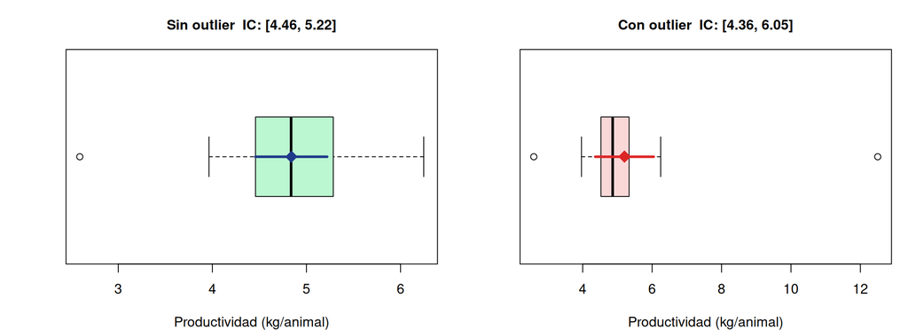

## IC con transformaciones: variables asimétricas

El problema de la asimetría

Muchas variables pecuarios son **log-normales** (productividad, concentraciones, conteos): $X > 0$ con distribución muy sesgada.

Para estas variables, el IC clásico puede incluir valores negativos y tener cobertura real inferior a la nominal.

**Solución:** aplicar transformación logarítmica antes de calcular el IC.

IC en escala log → volver a la original

```r
set.seed(9)
x <- exp(rnorm(25, mean=1.8, sd=0.5)) # log-normal
log_x <- log(x)
ic_log <- mean(log_x) + c(-1,1)*qt(0.975,24)*sd(log_x)/sqrt(25)
ic_orig <- exp(ic_log)  # volver a escala original
cat("IC 95% (escala log):", round(ic_log,3), "\n")
```

```
IC 95% (escala log): 1.573 1.979
```

```r
cat("IC 95% (escala orig):", round(ic_orig,2), "\n")
```

```
IC 95% (escala orig): 4.82 7.24
```

```r
cat("(asimétrico en escala original, correcto)\n")
```

```
(asimétrico en escala original, correcto)
```

El IC en la escala original es **asimétrico**, reflejando la asimetría de la distribución.

## Cobertura nominal vs real y bootstrap

Simulación de cobertura real

```r
set.seed(99)
cob <- function(dist_fn, mu, n, B = 2000)
  mean(replicate(B, {
    x  <- dist_fn(n)
    ic <- mean(x) + c(-1,1)*qt(0.975,n-1)*sd(x)/sqrt(n)
    ic[1] <= mu & mu <= ic[2]
  }))
ns <- c(5, 15, 30, 80)
cat("Normal :", sapply(ns, cob,
  dist_fn=function(n) rnorm(n,5,1), mu=5), "\n")
```

```
Normal : 0.937 0.947 0.9435 0.9525
```

```r
cat("Exp(1/5):", sapply(ns, cob,
  dist_fn=function(n) rexp(n,rate=1/5), mu=5), "\n")
```

```
Exp(1/5): 0.876 0.9135 0.9285 0.949
```

Bootstrap: inferencia sin supuestos

Usa la muestra como sustituto de la población. Genera $B$ remuestras con reemplazo y construye el IC con los percentiles de la distribución empírica del estadístico.

```r
set.seed(7)
x <- c(5.1,4.8,5.6,4.9,5.3,5.0,5.4,4.7)
boot_means <- replicate(4000,
  mean(sample(x, length(x), replace = TRUE)))
round(quantile(boot_means, c(0.025, 0.975)), 3)
```

```
 2.5% 97.5%
4.912 5.300
```

No requiere normalidad ni fórmulas cerradas.

## Aplicaciones inferenciales en zootecnia

Control de calidad

**Pregunta:** ¿El peso promedio de terneros Hass cumple el estándar de 280 g?

$\bar{x}=275$ g, IC 95%: [268, 282] g

El estándar está dentro del IC → no se concluye incumplimiento.

Ensayo de dietas

**Pregunta:** ¿Cuál es el productividad de la dieta experimental?

$\bar{x}=6.7$ kg/animal, IC 95%: [6.1, 7.3]

El IC no incluye el control (5.8) → posible superioridad de la dieta.

Vigilancia sanitaria

**Pregunta:** ¿La prevalencia de fusariosis supera el umbral de acción (10%)?

$\hat{p}=0.13$, IC 95%: [0.08, 0.18]

El IC contiene valores sobre 10% → considerar intervención.

**Reporte técnico completo:** estimador puntual + IC + nivel de confianza + $n$ y diseño + supuestos verificados.

## IC en R: funciones de referencia rápida

| Parámetro | Función en R | Argumentos clave |
| --- | --- | --- |
| Media ($\sigma$ desconocida) | `t.test(x, conf.level=0.95)` | `x`: vector de datos |
| Media ($\sigma$ conocida) | `z.test(x, sigma.x=..., conf.level=0.95)` | paquete `BSDA` |
| Proporción | `prop.test(x, n, conf.level=0.95)` | IC de Wilson por defecto |
| Diferencia de medias | `t.test(x, y, var.equal=TRUE)` | dos vectores |
| Medias pareadas | `t.test(x, y, paired=TRUE)` | orden importa |
| Varianza | `var.test(x, y)` | razón de varianzas |
| Bootstrap | `boot::boot()` + `boot.ci()` | paquete `boot` |

```r
# Ejemplo integrado: t.test devuelve IC automáticamente
x <- c(5.1,4.8,5.6,4.9,5.3,5.0,5.4,4.7,5.2,5.5)
resultado <- t.test(x, conf.level = 0.95)
cat("Media:", round(resultado$estimate, 3), "\n")
```

```
Media: 5.15
```

```r
cat("IC 95%:", round(resultado$conf.int, 3), "\n")
```

```
IC 95%: 4.933 5.367
```

## Reporte técnico: ejemplo completo en formato científico

Formato APA / reporte científico

1. **Descripción del diseño:** “Se seleccionó una MAS de $n=64$ animales de ganado (Huila, Colombia) del total de $N=2\,000$ en producción.”
2. **Estimación puntual:** “La producción media estimada fue $\bar{x}=2.6$ L/animal ($\widehat{\text{SE}}=0.10$ kg).”
3. **IC:** “IC al 95%: [2.40, 2.80] L/animal.”
4. **Supuestos:** “Se verificó normalidad (Shapiro-Wilk, $p=0.43$) e independencia de las observaciones.”

**Elementos obligatorios en cualquier reporte:**

- Estimador puntual con unidades.
- IC con nivel de confianza explícito.
- Tamaño de muestra y diseño utilizado.
- Supuestos verificados (normalidad, independencia).
- Interpretación en el contexto del problema.

## Ejemplo integrador: estudio completo de productividad

Estudio: ganancia de peso bovina en el Tolima bajo dos sistemas de alimentación

Se seleccionan aleatoriamente 30 corrales bajo alimentación por aspersión (A) y 25 bajo alimentación por goteo (G). Se mide el productividad (kg/animal). Se pide: IC para cada media, IC para la diferencia, verificación de supuestos y reporte técnico.

```r
set.seed(11)
A <- round(rnorm(30, mean=6.2, sd=1.0), 2)
G <- round(rnorm(25, mean=7.0, sd=0.9), 2)
cat("Aspersión: media=", round(mean(A),2),
    "  SE=", round(sd(A)/sqrt(30),3), "\n")
```

```
Aspersión: media= 5.87   SE= 0.132
```

```r
cat("Goteo:     media=", round(mean(G),2),
    "  SE=", round(sd(G)/sqrt(25),3), "\n")
```

```
Goteo:     media= 6.86   SE= 0.169
```

```r
ic_A <- mean(A) + c(-1,1)*qt(0.975,29)*sd(A)/sqrt(30)
ic_G <- mean(G) + c(-1,1)*qt(0.975,24)*sd(G)/sqrt(25)
cat("IC 95% Aspersión:", round(ic_A,2), "\n")
```

```
IC 95% Aspersión: 5.6 6.14
```

```r
cat("IC 95% Goteo:    ", round(ic_G,2), "\n")
```

```
IC 95% Goteo:     6.51 7.21
```

```r
Sp2 <- ((30-1)*var(A)+(25-1)*var(G))/(30+25-2)
e_dif <- qt(0.975,53)*sqrt(Sp2*(1/30+1/25))
dif   <- mean(G)-mean(A)
cat("IC 95% diferencia (G-A):", round(c(dif-e_dif,dif+e_dif),2),"\n")
```

```
IC 95% diferencia (G-A): 0.56 1.41
```

## Lectura de ICs en la literatura zootécnica

Cómo leer un IC en un artículo

Los artículos científicos reportan los ICs en varias formas equivalentes:

- $5.2 \pm 0.4$ kg/animal (media ± margen)
- $5.2$ [4.8, 5.6] kg/animal (media [LI, LS])
- $5.2$ (95% CI: 4.8–5.6) kg/animal

Verificar siempre: ¿qué nivel de confianza usaron? ¿$n$? ¿qué distribución (z o t)?

#### Interpretación en decisiones

- **ICs que se solapan:** no necesariamente implica que las medias no son diferentes, usar prueba formal.
- **IC muy amplio:** señal de $n$ insuficiente, el estudio carece de potencia para conclusiones firmes.
- **IC que no incluye un valor de referencia:** diferencia estadísticamente significativa respecto a ese valor.

## Taller en clase

## Taller 1: propiedades y IC para la media

Problema: proteína en animales de soya, Córdoba

El contenido de proteína (%) tiene $\sigma = 4\%$ (histórica). Muestra: $n = 16$, $\bar{x} = 39.2\%$.

1. Calcule $E(\bar{X})$ y $\text{SE}(\bar{X})$. ¿Es $\bar{X}$ insesgado?
2. Construya el IC al 95% usando $z$ y luego usando $t$. Compare.
3. ¿Qué $n$ necesitaría para un margen de $\pm 1\%$ con 95% de confianza?

## Taller 2: IC para proporción

Problema: pudrición de animal en bovinos, Tolima

De $n = 150$ animales inspeccionadas, $x = 42$ presentan síntomas.

1. Calcule $\hat{p}$ y verifique la condición de normalidad.
2. Construya el IC al 90% y al 99%.
3. ¿Qué $n$ necesitaría para $e = 0.03$ con 95% de confianza?

## Taller 3: IC bajo diseño estratificado

Problema: contenido de proteína en dietas, Cundinamarca

Se muestrea el contenido de N (g/kg) con diseño estratificado proporcional. Tres pisos altitudinales:

- Bajo ($N_1=300$, $n_1=15$): $\bar{x}_1=2.8$, $s_1=0.6$.
- Medio ($N_2=400$, $n_2=20$): $\bar{x}_2=3.5$, $s_2=0.8$.
- Alto ($N_3=300$, $n_3=15$): $\bar{x}_3=4.1$, $s_3=0.7$.

Calcule: (1) el estimador estratificado $\bar{x}_{st}$, (2) su varianza estimada, (3) IC al 95%.

## Resumen de la clase 13

Estimadores

- Funciones aleatorias: $\hat\theta = g(X_1,\ldots,X_n)$.
- Insesgado: $E(\hat\theta)=\theta$.
- $\text{ECM} = \text{Var} + B^2$.
- SE $\neq$ $s$: dispersión del estimador vs de los datos.
- Consistencia: converge con $n \to \infty$.

Intervalos de confianza

- $\bar{x} \pm z_{\alpha/2}\,\sigma/\sqrt{n}$ ($\sigma$ conocida / $n$ grande).
- $\bar{x} \pm t_{n-1}\,s/\sqrt{n}$ ($\sigma$ desconocida).
- $\hat{p} \pm z_{\alpha/2}\sqrt{\hat{p}(1-\hat{p})/n}$.
- Interpretación: el **método**, no el IC particular.

Factores y aplicaciones

- Amplitud $\propto \sigma$, $\propto z_{\alpha/2}$, $\propto 1/\sqrt{n}$.
- FPC si $n/N > 5\%$; DEFF para diseños complejos.
- Reportar: $\hat\theta$, IC, $n$, diseño, supuestos.
- Bootstrap para distribuciones no normales.

**Próxima clase:** Pruebas de hipótesis, cómo decidir si un parámetro cumple una condición con base en la evidencia muestral.